# GABA-AD: mixed models statistics

## Effect of pharmacological actvation of GABAARs

### Outcome variables

- **TEPs**: 5 components (= amplitudes)
  - **mean amplitude** across 25% of points from the window of interest, which are the most distant from 0
  - **latency** calculated from the median point included in the amplitude calculation
- **MEPs**: 1 component
  - peak-to-peak amplitude
- **RS-EEG**: 3 extracted variables
  - mean power across the lower beta band = **sigma peak**
  - **Alpha Attenuation Coefficient** (eyes closed/eyes open)
  - **Spectral Exponent** of the 1/f slope

All outcome variables are presented as the difference between the value post-medication and the value at baseline

### Fixed effects

- **MEDICATION**: alprazolam x placebo
  - binomial = 2 levels
- **STIMULUS**: CS x TS
  - binomial = 2 levels
- Covariate: **rMT change**
  - continuous value
- Covariate: **baseline value** of outcome variables
  - continuous value

### Random effects

- **SUBJECT**: to account for unknown interpersonal variability

Following pipeline treats each outcome measure separately, as an independent measure

## Data visualization

Load packages

Set graphic parameters for visualization

```r
# set graphic parameters for plots
par(cex = 2, font.main = 2)
par_def <- par()

# color palette - red/blue/purple/green(light + dark)
col_palette = c('cadetblue1', 'turquoise4', 'tomato1', 'red3', 'mediumorchid1', 'darkmagenta', 'olivedrab3', 'olivedrab4')
```

Import data in R-compatible long format

```r
data_all <- read.csv('C:/Users/uzivatel/UCL/O365G-NOCIONS - dsulcova/GABA-AD_results/Data/GABA_med_long.csv')
head(data_all, 10)
```

Choose the outcome variable of interest

```r
# define outcome variable of interest
variable <- c('P60', 'amplitude')

# choose columns to keep
vars_keep <- c('subject', 'medication', 'time', 'stimulus', 'peak', 'TEP', 'rMT')

# make into factors
data <- as_tibble(data_all[vars_keep])
data$subject <- factor(data$subject)
data$medication <- factor(data$medication)
data$time <- factor(data$time)
data$stimulus <- factor(data$stimulus)

# choose peak of interest
peak_names <- c('P30', 'N45', 'P60', 'N100', 'P180')
index <- which(peak_names == variable[1])
data <- data[data$peak == index, -5]

# calculate change post-medication
change <- data[data$time == 1, 5] - data[data$time == 0, 5]
data <- data[data$time == 0, -3] %>%
  rename_at(vars('TEP'), ~ as.character('baseline')) %>%
  add_column(change = deframe(change))
rm(change)
head(data, 10)
```

| subject | medication | stimulus | baseline | rMT | change |
| --- | --- | --- | --- | --- | --- |
| 1 | 0 | 0 | -0.59440607 | 43 | -0.06384633 |
| 1 | 0 | 1 | -0.67635217 | 43 | 0.36329523 |
| 1 | 1 | 0 | -0.06231942 | 43 | 0.27610048 |
| 1 | 1 | 1 | -0.19619674 | 43 | 0.47645881 |
| 2 | 0 | 0 | -1.01427231 | 55 | -0.37044370 |
| 2 | 0 | 1 | 1.38175116 | 55 | -0.82693247 |
| 2 | 1 | 0 | -1.52079949 | 56 | -0.89683824 |
| 2 | 1 | 1 | 1.13962340 | 56 | -0.27816679 |
| 3 | 0 | 0 | -0.52697012 | 60 | -1.31065338 |
| 3 | 0 | 1 | 1.99648495 | 60 | -0.59454455 |

Get basic descriptive statistics of the data

```r
describe <- function(x){
  print(round(c(mean = mean(x, na.rm = TRUE),
            median = median(x, na.rm = TRUE),
            min = min(x, na.rm = TRUE),
            max = max(x, na.rm = TRUE),
            std = sd(x, na.rm = TRUE)), digits = 4))}

# check variable at baseline
cat(paste(variable[1],  ' - baseline: \n'))
```

```
P60  - baseline:
```

```r
describe(data$baseline)
```

```
   mean  median     min     max     std
-0.8330 -0.7770 -5.4883  4.4638  1.8036
```

```r
cat('grouped by stimulus: \n')
```

```
grouped by stimulus:
```

```r
aggregate(baseline ~ stimulus, data = data, FUN = describe)
```

```
   mean  median     min     max     std
-0.5770 -0.6167 -1.8591  0.8446  0.6669
   mean  median     min     max     std
-1.0891 -1.4387 -5.4883  4.4638  2.4515
```

| stimulus | baseline |
| --- | --- |
| 0 |  |
| 1 |  |

```r
cat('grouped by medication: \n')
```

```
grouped by medication:
```

```r
aggregate(baseline ~ medication, data = data, FUN = describe)
```

```
   mean  median     min     max     std
-0.8322 -0.8030 -4.6924  4.4638  1.7127
   mean  median     min     max     std
-0.8339 -0.7654 -5.4883  3.7659  1.9120
```

| medication | baseline |
| --- | --- |
| 0 |  |
| 1 |  |

Visualize the data, test for normality

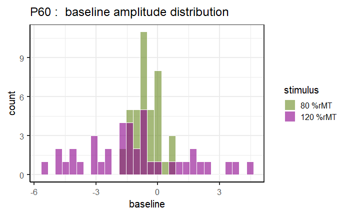

```r
# baseline
dist_bl <- data %>%
  ggplot(aes(x = baseline, fill = stimulus)) +
  geom_histogram(color = 'white', alpha = 0.6, position = 'identity') +
  scale_fill_manual(name = 'stimulus',
                    breaks = c(0, 1),
                    labels = c('80 %rMT', '120 %rMT'),
                    values = col_palette[c(8, 6)]) +
  ggtitle(paste(variable[1], ': ','baseline amplitude distribution')) +
  theme(text = element_text(size = 15),
        panel.background = element_rect(fill = 'white'),
        axis.line = element_line(colour = 'black'))
dist_bl
```

```r
# baseline - test of normality
shapiro.test(data$baseline[data$stimulus == 0 & data$medication == 0])
```

```
    Shapiro-Wilk normality test

data:  data$baseline[data$stimulus == 0 & data$medication == 0]
W = 0.98233, p-value = 0.9605
```

```r
shapiro.test(data$baseline[data$stimulus == 0 & data$medication == 1])
```

```
    Shapiro-Wilk normality test

data:  data$baseline[data$stimulus == 0 & data$medication == 1]
W = 0.95401, p-value = 0.4321
```

```r
shapiro.test(data$baseline[data$stimulus == 1 & data$medication == 0])
```

```
    Shapiro-Wilk normality test

data:  data$baseline[data$stimulus == 1 & data$medication == 0]
W = 0.9584, p-value = 0.5123
```

```r
shapiro.test(data$baseline[data$stimulus == 1 & data$medication == 1])
```

```
    Shapiro-Wilk normality test

data:  data$baseline[data$stimulus == 1 & data$medication == 1]
W = 0.96126, p-value = 0.5693
```

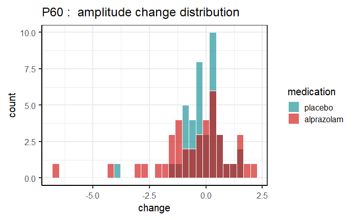

```r
# change
dist_change <- data %>%
  ggplot(aes(x = change, fill = medication)) +
  geom_histogram(color = 'white', alpha = 0.6, position = 'identity') +
  scale_fill_manual(name = 'medication',
                    breaks = c(0, 1),
                    labels = c('placebo', 'alprazolam'),
                    values = col_palette[c(2, 4)]) +
  ggtitle(paste(variable[1], ': ','amplitude change distribution')) +
  theme(text = element_text(size = 15),
        panel.background = element_rect(fill = 'white'),
        axis.line = element_line(colour = 'black'))
dist_change
```

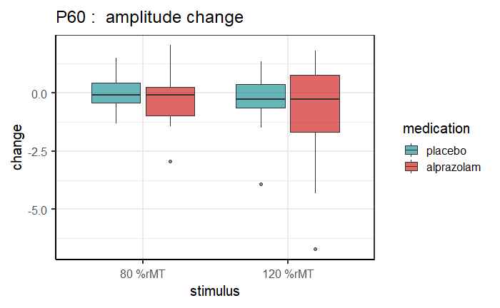

```r
box_change <- data %>%
  ggplot(aes(x = stimulus, y = change,  fill = medication)) +
  geom_boxplot(alpha = 0.6) +
  scale_fill_manual(name = 'medication',
                    breaks = c(0, 1),
                    labels = c('placebo', 'alprazolam'),
                    values = col_palette[c(2, 4)]) +
  scale_x_discrete(labels = c('0' = '80 %rMT', '1' = '120 %rMT')) +
  ggtitle(paste(variable[1], ': ','amplitude change')) +
  theme(text = element_text(size = 15),
        panel.background = element_rect(fill = 'white'),
        axis.line = element_line(colour = 'black'))
box_change
```

```r
# change - test of normality
data_test = data$change[data$stimulus == 0 & data$medication == 0]
shapiro.test(data_test)
```

```
    Shapiro-Wilk normality test

data:  data_test
W = 0.97891, p-value = 0.9192
```

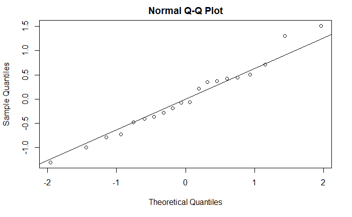

```r
qqnorm(data_test)
qqline(data_test)
```

```r
data_test = data$change[data$stimulus == 0 & data$medication == 1]
shapiro.test(data_test)
```

```
    Shapiro-Wilk normality test

data:  data_test
W = 0.95178, p-value = 0.3949
```

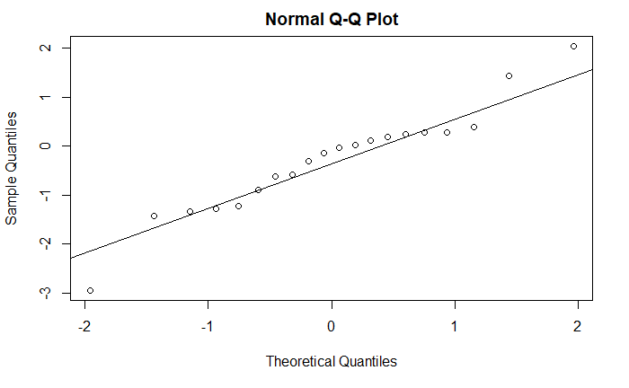

```r
qqnorm(data_test)
qqline(data_test)
```

```r
data_test = data$change[data$stimulus == 1 & data$medication == 0]
shapiro.test(data_test)
```

```
    Shapiro-Wilk normality test

data:  data_test
W = 0.83766, p-value = 0.003334
```

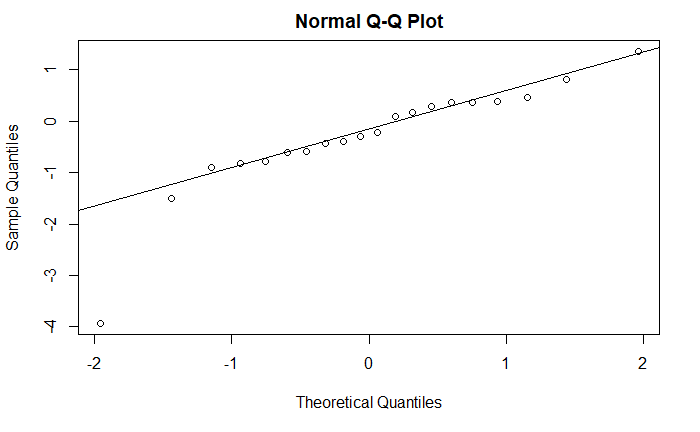

```r
qqnorm(data_test)
qqline(data_test)
```

```r
data_test = data$change[data$stimulus == 1 & data$medication == 1]
shapiro.test(data_test)
```

```
    Shapiro-Wilk normality test

data:  data_test
W = 0.89462, p-value = 0.03273
```

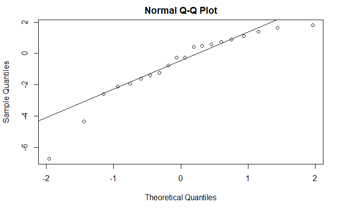

```r
qqnorm(data_test)
qqline(data_test)
```

```r
# homoscedasticity
leveneTest(change ~ medication, data = data[data$stimulus == 0, ], center = median)
```

```
Levene's Test for Homogeneity of Variance (center = median)
      Df F value Pr(>F)
group  1  1.2475 0.2711
      38
```

```r
leveneTest(change ~ medication, data = data[data$stimulus == 1, ], center = median)
```

```
Levene's Test for Homogeneity of Variance (center = median)
      Df F value  Pr(>F)
group  1  5.4884 0.02448 *
      38
---
Signif. codes:  0 ‘***’ 0.001 ‘**’ 0.01 ‘*’ 0.05 ‘.’ 0.1 ‘ ’ 1
```